# Midterm Project

Jing Yu

Mar 5, 2024

## Introduction

*“Provide background on your data sets and a clear formulated question or hypothesis.”*

The National Health Interview Survey (NHIS) is a vital source of information on the health of the civilian noninstitutionalized population of the United States. It is conducted by the National Center for Health Statistics (NCHS), which is part of the Centers for Disease Control and Prevention (CDC). With its comprehensive coverage of demographic, socioeconomic, and health-related factors, it provides an excellent platform for investigating the correlates of prevalent mental health disorders among adults, such as anxiety and depression. This study aims to **explore the relationships between prevalence of anxiety disorder and depression and various demographic, socioeconomic factors, and other health outcomes using the NHIS data from 2022**. Understanding these correlations can provide valuable insights into the determinants of mental health and inform public health policies and interventions.

## Methods

*“Include how and where the data were acquired, how you cleaned and wrangled the data, what tools you used for data exploration.”*

### Data Acquisition

The NHIS dataset for the year 2022 was acquired from the **Center for Disease Control and Prevention** website by directly downloading the CSV file, which is usually considered to be an reliable and original source: https://www.cdc.gov/nchs/nhis/2022nhis.htm

Upon downloading the dataset from the website, it was uploaded to a GitHub repository in CSV file format for the convenience of this project.

The dataset has `27651` observations and `637` variables.

```r
fn1 <- "https://raw.githubusercontent.com/angelaaajing/JSC370-Project/main/adult22.csv"

if (!file.exists("adult22.csv"))
  download.file(fn1, destfile = "adult22.csv")
NHIS_df <- data.table::fread("adult22.csv")
```

### Data Wrangling and Cleaning

Unrelated columns in the dataset `NHIS_df` were dropped, keeping only relevant information related to demographic factors, socioeconomic factors, other health outcomes, and mental health disorders.

Demographic factors:

- `REGION`: Household region
- `SEX_A`: Sex of Sample Adult
- `AGEP_A`: Age of SA (top coded)

Socioeconomic factors:

- `MAXEDUCP_A`: Highest level of education of all the adults in the SA’s family
- `RATCAT_A`: Ratio of family income to poverty threshold for SA’s family

Other health outcomes:

- `BMICAT_A`: Categorical Body Mass Index, Public Use
- `CANEV_A`: Ever been told you had cancer
- `HYPEV_A`: Ever been told you had hypertension
- `CHLEV_A`: Ever told you had high cholesterol
- `ARTHEV_A`: Ever had arthritis
- `DIBEV_A`: Ever had diabetes
- `COPDEV_A`: Ever been told you had COPD, emphysema, or chronic bronchitis?
- `VISIONDF_A`: Difficulty seeing
- `HEARINGDF_A`: Difficulty hearing
- `DIFF_A`: Difficulty walking/steps
- `COMDIFF_A`: Difficulty communicating
- `COGMEMDFF_A`: Difficulty remembering/concentrating

Mental health disorders:

- `ANXEV_A`: Ever had anxiety disorder
- `DEPEV_A`: Ever had depression

```r
NHIS_df <- NHIS_df[, c("REGION", "SEX_A", "AGEP_A", "MAXEDUCP_A", "RATCAT_A",
                       "BMICAT_A", "CANEV_A", "HYPEV_A", "CHLEV_A", "ARTHEV_A",
                       "DIBEV_A", "COPDEV_A", "VISIONDF_A", "HEARINGDF_A",
                       "DIFF_A", "COMDIFF_A", "COGMEMDFF_A", "ANXEV_A", "DEPEV_A")]
```

Check the dimensions, headers, footers, variable types and summary statistics of the dataset. The dataset now has `19` variables with `27651` observations. By looking at the headers and footers of the dataset, they seems to be imported correctly. All variables are numerical, referring to some categorical values.

```r
dim(NHIS_df)
head(NHIS_df)
tail(NHIS_df)
str(NHIS_df)
summary(NHIS_df)
```

[output not shown]

Since there are too many factors for analysis, I would categorize relevant variables into one, such as chronic conditions and disability status. If an individual had any kinds of chronic conditions/disabilities, return ‘Yes’. If an individual didn’t have any kinds of chronic conditions/disabilities, return ‘No’. Otherwise, replace with NAs. Rename columns for readability and convert numerical categorical values to factors in the `NHIS_df` dataset.

```r
clean_df <- NHIS_df |>
  mutate(
    Chronic_cond = case_when(
      HYPEV_A == 1 | CHLEV_A == 1 | ARTHEV_A == 1 | DIBEV_A == 1 | COPDEV_A == 1 ~ "Yes",
      HYPEV_A == 2 & CHLEV_A == 2 & ARTHEV_A == 2 & DIBEV_A == 2 & COPDEV_A == 2 ~ "No",
      TRUE ~ NA_character_
      ),
    Disability = case_when(
      VISIONDF_A == 2 | VISIONDF_A == 3 | VISIONDF_A == 4 |
        HEARINGDF_A == 2 | HEARINGDF_A == 3 | HEARINGDF_A == 4 |
        DIFF_A == 2 | DIFF_A == 3 | DIFF_A == 4 |
        COMDIFF_A == 2 | COMDIFF_A == 3 | COMDIFF_A == 4 |
        COGMEMDFF_A == 2 | COGMEMDFF_A == 3 | COGMEMDFF_A == 4  ~ "Yes",
      VISIONDF_A == 1 & HEARINGDF_A == 1 & DIFF_A == 1 &
        COMDIFF_A == 1 & COGMEMDFF_A == 1 ~ "No",
      TRUE ~ NA_character_
      ),
    Region = case_when(
      REGION == 1 ~ "Northeast",
      REGION == 2 ~ "Midwest",
      REGION == 3 ~ "South",
      REGION == 4 ~ "West",
      TRUE ~ NA_character_
      ),
    Sex = case_when(
      SEX_A == 1 ~ "Male",
      SEX_A == 2 ~ "Female",
      TRUE ~ NA_character_
      ),
    Education = case_when(
      MAXEDUCP_A <= 04 ~ "High school or lower",
      MAXEDUCP_A == 05 ~ "Some college without degree",
      MAXEDUCP_A == 06 | MAXEDUCP_A == 07 ~ "Associate degree",
      MAXEDUCP_A == 08 ~ "Bachelor's degree",
      MAXEDUCP_A == 09 ~ "Master's degree",
      MAXEDUCP_A == 10 ~ "Professional School / Doctoral degree",
      TRUE ~ NA_character_
      ),
    Income = case_when(
      RATCAT_A <= 03 ~ "Poverty",
      RATCAT_A >= 04 & RATCAT_A <= 09 ~ "Low-Income",
      RATCAT_A >= 10 & RATCAT_A <= 13 ~ "Middle-Income",
      RATCAT_A == 14 ~ "High-Income",
      TRUE ~ NA_character_
      ),
    BMI = case_when(
      BMICAT_A == 1 ~ "Underweight",
      BMICAT_A == 2 ~ "Healthy weight",
      BMICAT_A == 3 ~ "Overweight",
      BMICAT_A == 4 ~ "Obese",
      TRUE ~ NA_character_
      ),
    Cancer = case_when(
      CANEV_A == 1 ~ "Yes",
      CANEV_A == 2 ~ "No",
      TRUE ~ NA_character_
      ),
    Disorder = case_when(
      ANXEV_A == 1 | DEPEV_A == 1 ~ "Yes",
      ANXEV_A == 2 & DEPEV_A == 2 ~ "No",
      TRUE ~ NA_character_
      ),
    Age = ifelse(AGEP_A >= 97, NA_integer_, AGEP_A)
  ) |>
  select(Region, Sex, Age, Education, Income, BMI, Cancer,
         Chronic_cond, Disability, Disorder)
```

After checking the percentage of missing values in each variable, all of them contains only small percent of missing values. Therefore, I removed row with NA values. Now, the dataset has `10` variables with `26819` observations.

```
##       Region          Sex          Age    Education       Income          BMI
##   0.00000000   0.01084952   0.23145637   0.31825250   0.00000000   2.26393259
##       Cancer Chronic_cond   Disability     Disorder
##   0.13381071   0.23868938   0.04339807   0.20252432
```

```
## [1] 26819    10
```

### Data Exploration

For Exploratory Data Analysis (EDA), I utilized various types of graphs to explore the relationships between different variables. These included:

- Histograms: To visualize the Proportion of Disorder by Age.
- Bar Plots: To illustrate the proportion of anxiety and depression.
- Proportional bar plots: To show the prevalence of anxiety and depression in different categories of the categorical variables.

## Preliminary Results

*“Provide summary statistics in tabular from and publication-quality figures, take a look at the kable function from knitr to write nice tables in Rmarkdown”*

### Summary Statistics

Below is a summary table of key statistics derived from the cleaned NHIS dataset:

Summary Statistics of NHIS Dataset

| Region | Sex | Count | Mean_Age | Median_Age | Min_Age | Max_Age | Prop_Disorder |
| --- | --- | --- | --- | --- | --- | --- | --- |
| Midwest | Female | 3123 | 54.71278 | 57 | 18 | 85 | 0.3336535 |
| Midwest | Male | 2753 | 52.33927 | 54 | 18 | 85 | 0.1965129 |
| Northeast | Female | 2379 | 54.26776 | 56 | 18 | 85 | 0.2858344 |
| Northeast | Male | 2035 | 52.88600 | 55 | 18 | 85 | 0.1793612 |
| South | Female | 5425 | 53.34359 | 55 | 18 | 85 | 0.2927189 |
| South | Male | 4452 | 52.39645 | 54 | 18 | 85 | 0.1758760 |
| West | Female | 3495 | 52.57339 | 53 | 18 | 85 | 0.2864092 |
| West | Male | 3157 | 51.01489 | 51 | 18 | 85 | 0.1723155 |

Summary Statistics of Demographic Factors by Anxiety Disorder Status

| Disorder | Mean_Age | Median_Age | Proportion_Male | Proportion_Female | Proportion_Chronic_Condition | Proportion_Disability |
| --- | --- | --- | --- | --- | --- | --- |
| No | 53.53721 | 55 | 0.5013070 | 0.4986930 | 0.5396301 | 0.4102589 |
| Yes | 50.98915 | 51 | 0.3412286 | 0.6587714 | 0.6621333 | 0.6667176 |

Summary Statistics of Socioeconomic Factors by Disorder Status

| Disorder | Proportion_Poverty | Proportion_Low_Income | Proportion_Middle_Income | Proportion_High_Income |
| --- | --- | --- | --- | --- |
| No | 0.0844390 | 0.3178298 | 0.2487300 | 0.3490012 |
| Yes | 0.1445599 | 0.3675122 | 0.2333435 | 0.2545844 |

### Visualization

Bar plots used to illustrate the proportion of anxiety and depression.

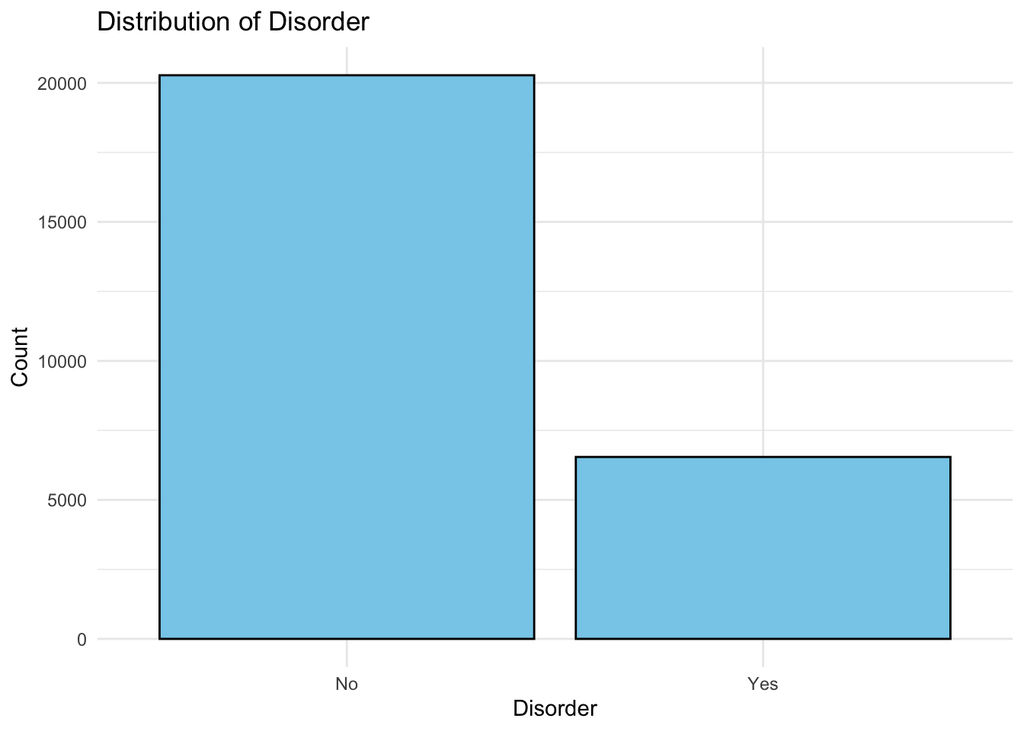

Histogram used to visualize the Proportion of Disorder by Age.

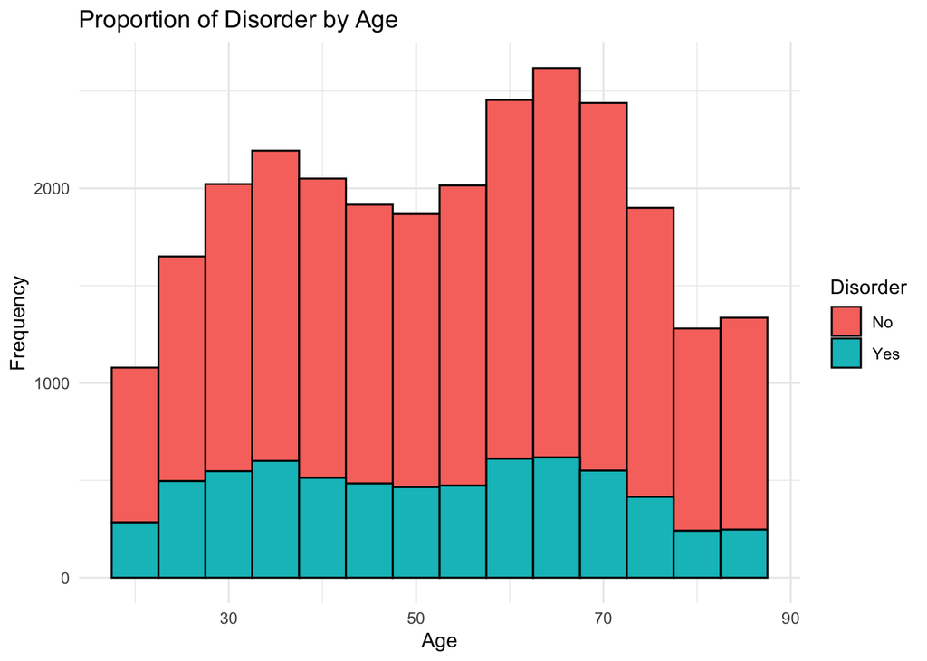

Proportional barplots to show the prevalence of anxiety and depression in different categories of the categorical variables.

[figure not shown]

[figure not shown]

### Models

I fitted linear model between disorder and different factors to check whether the variable is statistically significant.

```r
clean_df[, Disorder := ifelse(Disorder == "Yes", 1, 0)]

# Demographic factors
demo_lm <- lm(Disorder ~ Region + Sex + Age, clean_df)
summary(demo_lm)
```

```
##
## Call:
## lm(formula = Disorder ~ Region + Sex + Age, data = clean_df)
##
## Residuals:
##     Min      1Q  Median      3Q     Max
## -0.3807 -0.2796 -0.1954 -0.1239  0.8822
##
## Coefficients:
##                   Estimate Std. Error t value Pr(>|t|)
## (Intercept)      0.4083462  0.0097416  41.918  < 2e-16 ***
## RegionNortheast -0.0335151  0.0084508  -3.966 7.33e-05 ***
## RegionSouth     -0.0325506  0.0069913  -4.656 3.24e-06 ***
## RegionWest      -0.0391122  0.0075998  -5.146 2.67e-07 ***
## SexMale         -0.1211835  0.0052015 -23.298  < 2e-16 ***
## Age             -0.0015330  0.0001407 -10.898  < 2e-16 ***
## ---
## Signif. codes:  0 '***' 0.001 '**' 0.01 '*' 0.05 '.' 0.1 ' ' 1
##
## Residual standard error: 0.4243 on 26813 degrees of freedom
## Multiple R-squared:  0.0244, Adjusted R-squared:  0.02421
## F-statistic: 134.1 on 5 and 26813 DF,  p-value: < 2.2e-16
```

```r
# Socioeconomic factors
soc_lm <- lm(Disorder ~ Income + Education, clean_df)
summary(soc_lm)
```

```
##
## Call:
## lm(formula = Disorder ~ Income + Education, data = clean_df)
##
## Residuals:
##     Min      1Q  Median      3Q     Max
## -0.3907 -0.2478 -0.2018 -0.1443  0.8557
##
## Coefficients:
##                                                  Estimate Std. Error t value
## (Intercept)                                     0.1995975  0.0085306  23.398
## IncomeLow-Income                                0.0968897  0.0072735  13.321
## IncomeMiddle-Income                             0.0482287  0.0072215   6.679
## IncomePoverty                                   0.1888255  0.0103736  18.203
## EducationBachelor's degree                     -0.0162629  0.0087903  -1.850
## EducationHigh school or lower                  -0.0552634  0.0088432  -6.249
## EducationMaster's degree                        0.0022385  0.0100261   0.223
## EducationProfessional School / Doctoral degree -0.0008426  0.0131311  -0.064
## EducationSome college without degree           -0.0025008  0.0098247  -0.255
##                                                Pr(>|t|)
## (Intercept)                                     < 2e-16 ***
## IncomeLow-Income                                < 2e-16 ***
## IncomeMiddle-Income                            2.46e-11 ***
## IncomePoverty                                   < 2e-16 ***
## EducationBachelor's degree                       0.0643 .
## EducationHigh school or lower                  4.19e-10 ***
## EducationMaster's degree                         0.8233
## EducationProfessional School / Doctoral degree   0.9488
## EducationSome college without degree             0.7991
## ---
## Signif. codes:  0 '***' 0.001 '**' 0.01 '*' 0.05 '.' 0.1 ' ' 1
##
## Residual standard error: 0.4262 on 26810 degrees of freedom
## Multiple R-squared:  0.01573,    Adjusted R-squared:  0.01544
## F-statistic: 53.57 on 8 and 26810 DF,  p-value: < 2.2e-16
```

```r
# Other health outcomes
health_lm <- lm(Disorder ~ BMI + Cancer + Chronic_cond + Disability, clean_df)
summary(health_lm)
```

```
##
## Call:
## lm(formula = Disorder ~ BMI + Cancer + Chronic_cond + Disability,
##     data = clean_df)
##
## Residuals:
##     Min      1Q  Median      3Q     Max
## -0.4102 -0.3071 -0.1521 -0.1172  0.8966
##
## Coefficients:
##                  Estimate Std. Error t value Pr(>|t|)
## (Intercept)      0.131686   0.005359  24.575  < 2e-16 ***
## BMIObese         0.046925   0.006505   7.214 5.60e-13 ***
## BMIOverweight   -0.013721   0.006339  -2.165 0.030423 *
## BMIUnderweight   0.068983   0.020680   3.336 0.000852 ***
## CancerYes       -0.014528   0.007929  -1.832 0.066941 .
## Chronic_condYes  0.034137   0.005561   6.139 8.44e-10 ***
## DisabilityYes    0.175428   0.005403  32.468  < 2e-16 ***
## ---
## Signif. codes:  0 '***' 0.001 '**' 0.01 '*' 0.05 '.' 0.1 ' ' 1
##
## Residual standard error: 0.4177 on 26812 degrees of freedom
## Multiple R-squared:  0.05438,    Adjusted R-squared:  0.05417
## F-statistic:   257 on 6 and 26812 DF,  p-value: < 2.2e-16
```

## Summary

*“What you found so far from your data in terms of the formulated question.”*

From the summary of the fitted linear models, we can analyze the results in the following aspects:

Model for Demographic factor:

- Adjusted R-squared: 0.02421
- Significance of Coefficients: Most coefficients are highly significant (p < 0.05).
- Residual Standard Error: 0.4243

Model for Socioeconomic factor:

- Adjusted R-squared: 0.01544
- Significance of Coefficients: Some coefficients are not significant (e.g., EducationMaster’s degree, EducationProfessional School / Doctoral degree).
- Residual Standard Error: 0.4262

Therefore, Model for other health outcomes: (Disorder ~ BMI + Cancer + Chronic_cond + Disability) appears to be the best model among the three for predicting the prevalence of the disorder based on the provided information.

Inclusion, other health outcomes seems to affect the prevalance of disorder most.